# Demo1

[AMath 586, Spring Quarter 2019](http://staff.washington.edu/rjl/classes/am586s2019/) at the University of Washington. For other notebooks, see Index.html or the [Index of all notebooks on Github](https://github.com/rjleveque/amath586s2019/blob/master/notebooks/Index.html).

This notebook just illustrates a few things to make simple plots.

### Import a bunch of stuff and make plots appear inline:

The following notebook "magic" command makes plots show up in the notebook in a manner that you can interact with them, e.g. zooming in. If you give plot commands in more than one cell you should close earlier figures before plotting new ones, or start each such cell with a `figure` command.

(Instead use `%matplotlib inline` to get them to show up in notebook but not be interactive.)

```python
%matplotlib notebook
```

The next line imports many things from [numpy](http://www.numpy.org/) and [matplotlib](http://matplotlib.org/), including things like `pi`, `sin`, `linspace`, and `plot` that are used below.

```python
from pylab import *
```

```python
x = linspace(0, 4*pi, 100)
```

```python
y = x*x + x**3*sin(x)
```

### Make a plot

Here is a plot of $f(x) = x^2 + x^3\sin(x)$.

```python
figure(figsize=(6,4))
plot(x,y,'r')
```

[output not shown]

Make another version that has different colored points and line.

Also save the result as a `png` file that can be downloaded.

```python
x = linspace(0, 4*pi, 50)
y = x*x + x**3*sin(x)

figure(figsize=(6,4))
plot(x, y, 'r-')
plot(x, y, 'bo')

title('My plot')
grid(True)
savefig('myplot.png')
```

We can also display this png file (or any other image) inline:

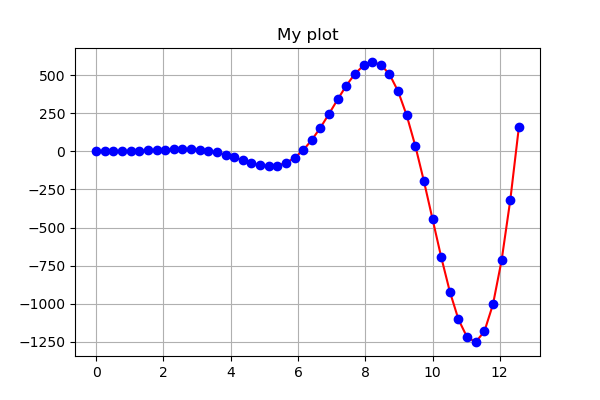

```python
from IPython.display import Image
Image('myplot.png')
```

### For help with plotting:

See the [matplotlib gallery](http://matplotlib.org/gallery.html) for many examples.